# Lab 13 - Coevolution of Networks and Behavior with Stochastic Actor-Based Models (SABMs) in R

CRJ 605 Statistical Analysis of Networks

In the Coevolution of Networks and Behavior using Stochastic Actor-Based Models (SABMs) lecture) you were introduced to the basic logic of coevolution of networks and behavior. This lab draws on that content, showing you how to estimate coevolution SABMs using the `RSiena` package. For WAY MORE details about `RSiena`, please review the [RSiena manual](http://www.stats.ox.ac.uk/~snijders/siena/RSiena_Manual.pdf).

# **Coevolution for the PINS *Get Along With* Networks**

Recall that with SABMs, we are trying to build a model that accurately represents the preferences among actors that generated the observed network between discrete time points. In addition, we would like to incorporate the changes that occur in behavior as a consequence of network position. As a result, we need to examine a *coevolution* model of the network and behavior. In other words, we want to examine the simultaneity of **network dynamics** and **behavior dynamics**.

## **The Networks**

Let’s again use two waves of data from the PINS study to examine how *get along with* nominations change over two waves. There are two network objects available on the SNA Textbook website:

```r
# clear the workspace
rm( list = ls() )


# libraries needed
library( sna )     # for sna functions
library( network ) # for working with network objects
library( RSiena )  # for working with SABMs


# define the path location for the file
loc1 <- "https://github.com/jacobtnyoung/sna-textbook/raw/main/data/data-pins-ga-panel-w1-net.rds"
gaNetT1 <- readRDS( url( loc1 ) )

loc2 <- "https://github.com/jacobtnyoung/sna-textbook/raw/main/data/data-pins-ga-panel-w2-net.rds"
gaNetT2 <- readRDS( url( loc2 ) )

# look at the network for wave 1
gaNetT1
```

```
##  Network attributes:
##   vertices = 73
##   directed = TRUE
##   hyper = FALSE
##   loops = FALSE
##   multiple = FALSE
##   bipartite = FALSE
##   total edges= 213
##     missing edges= 0
##     non-missing edges= 213
##
##  Vertex attribute names:
##     depression.w1 depression.w2 race smoker.w1 smoker.w2 socdist.w1 socdist.w2 vertex.names
##
## No edge attributes
```

```r
# look at the network for wave 2
gaNetT2
```

```
##  Network attributes:
##   vertices = 73
##   directed = TRUE
##   hyper = FALSE
##   loops = FALSE
##   multiple = FALSE
##   bipartite = FALSE
##   total edges= 186
##     missing edges= 0
##     non-missing edges= 186
##
##  Vertex attribute names:
##     depression.w1 depression.w2 race smoker.w1 smoker.w2 socdist.w1 socdist.w2 vertex.names
##
## No edge attributes
```

## **The Attributes**

Now, let’s pull in the attributes. We will use the **social distance** scale from the PINS survey. The variable is calculated by taking the average of four items asking participants to state their level of agreement with statements about people of another race: 1) “I would share a table with them”; 2) “I would cooperate with them if needed”; 3) “I would accept them as personal friends”; and 4) “I would avoid them if I could” (reverse-coded). Responses to each statement were on a 5-point Likert scale ranging from “strongly agree” to “strongly disagree”. Therefore, higher values indicate greater feelings of social distance from people of another race.

In the prior lab, we only used one wave of the data, treating this as a “constant covariate”. Here, we are going to use both waves since it is a **dependent** variable.

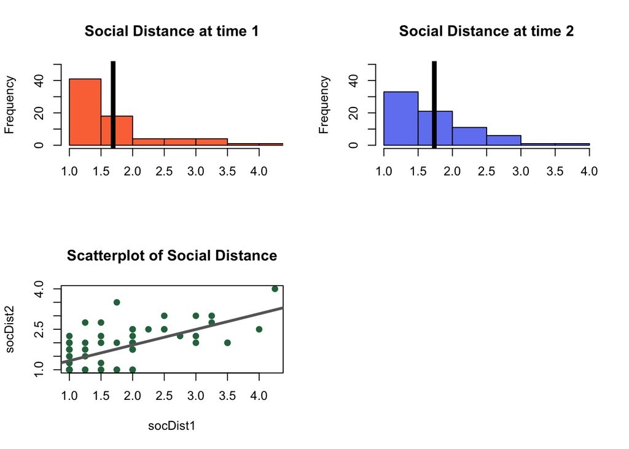

```r
# pull off the social distance scale for each wave
socDist1 <- gaNetT1 %v% "socdist.w1"
socDist2 <- gaNetT2 %v% "socdist.w2"


# build a plot of these
par( mfrow = c( 2,2 ) )

# plot the first wave with a line for the mean
hist( socDist1,
      col = "#fc7544",
      main = "Social Distance at time 1",
      ylim = c( 0, 50 ),                           # set the limits for the y-axis
      xlim = c( min( socDist1 ), max( socDist1 ) ), # set the limits for the x-axis
      xlab = ""                                    # supress the label for the x-axis
      )
abline( v = mean( socDist1 ),
        lwd = 5,
        col = "black"
        )

# plot the first wave with a line for the mean
hist( socDist2,
      col = "#7285f2",
      main = "Social Distance at time 2",
      ylim = c( 0, 50 ),                           # set the limits for the y-axis
      xlim = c( min( socDist2 ), max( socDist2 ) ), # set the limits for the x-axis
      xlab = ""                                    # supress the label for the x-axis
      )
abline( v = mean( socDist2 ),
        lwd = 5,
        col = "black"
        )

# plot a scatterplot
plot( socDist1, socDist2,                     # plot the two waves of data
      col = "#28734a",
      pch = 19,                               # make the character solid circles
      main = "Scatterplot of Social Distance"
      )
abline( lm( socDist2 ~ socDist1 ),            # the line is the OLS
        col = "grey40",
        lwd = 3
        )
```

*What do the plots tell us about changes in social distance over time?*

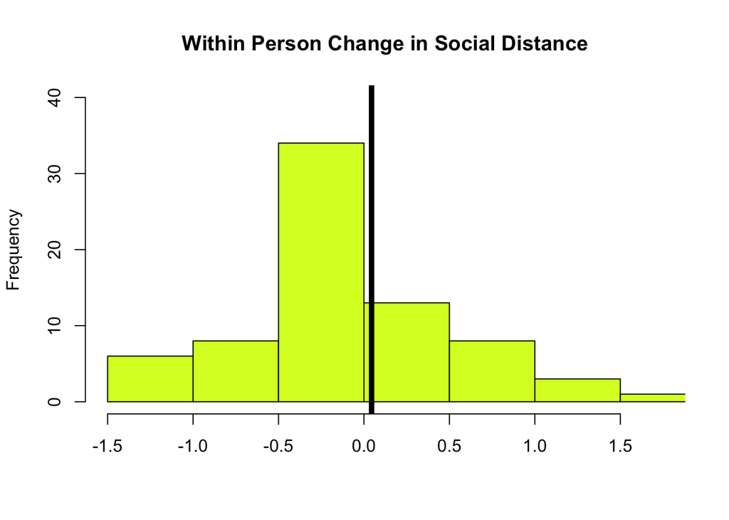

```r
# reset the window partition
par( mfrow = c( 1, 1 ) )

# create the deviations
socDistD <- socDist2 - socDist1

# plot the within person deviations
hist( socDistD,
      col = "#d7fa28",
      main = "Within Person Change in Social Distance",
      ylim = c( 0, 40 ),                           # set the limits for the y-axis
      xlim = c( min( socDistD ), max( socDistD ) ), # set the limits for the x-axis
      xlab = ""                                    # supress the label for the x-axis
      )
abline( v = mean( socDistD ),
        lwd = 5,
        col = "black"
        )
```

*What’s the take-away?*

Mainly, that some people go up, some go down, and a lot stay the same. So, let’s think about: *why some go up? down?*

# **Coevolution of the *Get Along With* Network and the *Social Distance* Scale**

As we have seen, for an RSiena analysis, we have to build several objects. The objects will serve as variables:

- A data object to examine (using `sienaDependent()` and `sienaDataCreate()`).
- A set of effects to estimate (using `getEffects` and `includeEffects()`).
- A model object that will have the terms we want to estimate (using `sienaAlgorithmCreate` or `sienaModelCreate()`).
- Then, we estimate the model using `siena07()`.

## **Step 1: Building the object to analyze using the `sienaDependent()` and `sienaDataCreate()` functions**

Since we are examining coevolution, we will have two dependent variables:

- The *get along with* network
- The *social distance* scale

We will need to create two dependent variables using the `sienaDependent()` function. *Note* that this is a different approach from defining *performance* using the `coCovar()` function.

Let’s go ahead and create our dependent variables. We will create our get along with dependent variable the same way. But, for the social distance dependent variable, we need to use the `type=` argument in the `sienaDependent()` function. Specifically, we need to state `type="behavior"` as the default is `type="oneMode"`.

After we have defined each of these dependent variables, we will bind them together using the `sienaDataCreate()` function.

```r
# look at the type= argument
?sienaDependent

# build the network object to examine
getalong <- sienaDependent(
  array(                        # define that it is an array
    c( as.matrix( gaNetT1 ),
       as.matrix( gaNetT2 ) ),  # define the two networks (matrices)
    dim=c( 73, 73, 2 )          # n x n x t are the dimensions
    )
  )

# build the social distance variable
socDist <- sienaDependent(
  cbind( socDist1, socDist2 ), # sienaDependent requires a matrix, so we use cbind
  type = "behavior"
)

# bind data together for Siena analysis
CoEvolutionData <- sienaDataCreate( getalong, socDist )
```

## **Step 2: Defining the set of effects to estimate using the `getEffects()` function**

Now, we create an effects object for model specification using the `getEffects()` function. Basically, we are going to create an object with some effects, then as we continue to build our model, we can add or remove effects from that object. To see how this function works, look at the help with `?getEffects`.

By default, the `getEffects` function will estimate the rate of change in each period (i.e. the **rate** function). In this example, we will see one rate estimated, the rate of change from t1:t2 (rate 1). If we had more waves (i.e. time points), then we would more rates. Also, the model automatically adds the *outdegree* and *reciprocity* terms as these are necessary for estimation.

```r
# create the effects object
CoEvolutionEffects <- getEffects( CoEvolutionData )
```

## **Step 3: Create the model using the `sienaAlgorithmCreate` and `sienaModelCreate()` functions**

```r
# create a model that has particulars about estimation, then we estimate the model
CoEvolutionModel <- sienaModelCreate(
  projname = "Get Along & Social Distance",  # the output on model fit and convergence will be stored in a text file with this name
  seed=605                          # set the seed to reproduce model results
  )
```

```
## If you use this algorithm object, siena07 will create/use an output file Get Along & Social Distance.txt .
```

## **Step 4: Estimate the model using the `siena07` function**

Now we are ready to estimate the model! To do this, we pass to the `siena07()` function the model information, the data, and the effects. Recall that we have included the basic effects using the `getEffects()` function. Let’s take a look at this very simple model to see how the network and the behavior are changing over the periods.

```r
# estimate the model
CoEvolutionResults <- siena07(
    CoEvolutionModel,           # the model estimation information
    data=CoEvolutionData,       # the data object we created above
    effects=CoEvolutionEffects  # the effects object we created above
)

# look at the results
CoEvolutionResults
```

```
## Estimates, standard errors and convergence t-ratios
##
##                                         Estimate   Standard   Convergence
##                                                      Error      t-ratio
## Network Dynamics
##   1. rate basic rate parameter getalong  6.4098  ( 0.6023   )    0.0354
##   2. eval outdegree (density)           -2.1271  ( 0.0817   )   -0.0423
##   3. eval reciprocity                    1.6905  ( 0.1800   )   -0.0242
##
## Behavior Dynamics
##   4. rate rate socDist period 1          1.3912  ( 0.3580   )    0.0116
##   5. eval socDist linear shape          -0.2200  ( 0.2499   )    0.0686
##   6. eval socDist quadratic shape       -0.5121  ( 0.3893   )    0.0415
##
## Overall maximum convergence ratio:    0.0950
##
##
## Total of 2669 iteration steps.
```

### **Interpreting the Output**

We estimate a **coevolution model**, we get two sets of estimates:

- Network Dynamics
- Behavior Dynamics

#### **Network Dynamics**

The **rate** estimates correspond to the estimated number of opportunities for change per actor for each period. The estimate is `6.4098`, meaning that each actor had just over 6 opportunities to change a tie or maintain their current tie configuration between t0 and t1 (i.e. wave 1 and wave 2). Put differently, to get from the first network to the second network, there are about 6 x 73 = 438 “decisions” made over the actors.

The `eval outdegree` term is negative, suggesting that individuals prefer *not* to send ties. Put differently, the agent, when given the opportunity in a micro-step, says “huh, what can I do? I can send a tie or not. I prefer not to”.

The `eval reciprocity` term is positive, indicating that individuals prefer to reciprocate ties. Note that this preference is for *maintaining* an existing reciprocated relationship, for *creating* a reciprocated relationship from an asymmetric relationship where alter has nominated ego (i.e. ego wants to reciprocate), and for *dissolving* an asymmetric relationship where alter did not nominated ego after ego nominated alter (i.e. alter didn’t reciprocate).

#### **Behavior Dynamics**

The output shows the estimates for the **rate** function and the estimates for the **objective** function. For each coefficient, we see an estimate, a standard error, and a convergence *t*-ratio.

The **rate** estimates correspond to the estimated number of opportunities for each actor to change their *behavior* for each period. Keep in mind that these are not units of change (e.g. standard deviation change), but opportunities in the simulation to make a change. Recall that the model is simulating *micro-steps*, and in each micro-step an individual is provided the opportunity to make a decision. The **rate** parameter estimate gives a sense of how many opportunities are provided to each individual. For example, the estimate for period 1 is `1.3912`, meaning that each actor had nearly slight more than 1 opportunity to change his/her social distance score or maintain their current social distance score. The *shape* parameters show that between waves, social distance did not decline (the terms are not significantly different from zero.

As before, the significance of the effects can be evaluated in a manner similar to a regression coefficient by looking at the ratio of the estimate to the standard error (where a ratio of 1.96 indicates a *p*-value of *0.05*).

*Are these estimates of no average change in the social distance variable consistent with what we observed in our plots above?*

## **Step 5: Adding Terms to the Model**

### **Specifying Coevolution Terms**

So far, our model has not specified any dependence terms between the *get along with* network and the *social distance* variable. In other words, we are allowing these variables to evolve **independently**. Let’s take a look at including terms where:

- The behavior influences the network (e.g. `egoX`, `alterX`, and `sameX` or `simX`)
- The network influences the behavior (e.g. `indeg`, `outdeg`, and `avSim`)

#### **Behavior Effects on the Network**

Now we want to include the effects of `socDist` on tie behavior. Recall that for actor covariates, we call these *interaction terms* because the outdegree depends on a covariate. We use the same syntax as we did in the prior lab for specifying these terms.

Let’s use the terms we used from the prior lab:

- Individuals with a particular attribute are more likely to *send* ties, a *sender* effect (this effect is called `egoX`).
- Individuals with a particular attribute are more likely to *receive* ties, a *receiver* effect (this effect is called `altX`).
- Individuals with a particular attribute are more likely to nominate others with the same or similar attribute, a *homophily* effect (this effect is called `sameX` or `simX`).

```r
CoEvolutionEffects <- includeEffects(
  CoEvolutionEffects, # the existing effects object.
    # now the terms:
    egoX, # social distance influences tie sending
    altX, # social distance influences tie receiving
    simX, # homophily for social distance
  interaction1 = "socDist" # define the variable of interest
)
```

```
##   effectName         include fix   test  initialValue parm
## 1 socDist alter      TRUE    FALSE FALSE          0   0
## 2 socDist ego        TRUE    FALSE FALSE          0   0
## 3 socDist similarity TRUE    FALSE FALSE          0   0
```

#### **Network Effects on Behavior**

Now we want to include the effects of the *get along with* network on the measure of *social distance*. The notion of *interaction* is the same here, but we want to see how behavior depends on a tie (rather than *visa versa*).

Here are some common terms:

- Tie *sending* influences behavior (this effect is called `outdeg`).
- Tie *receiving* influences behavior (this effect is called `indeg`).
- The behavior of those whom you are tied to influences your behavior (this effect is called `avSim`).

Let’s add these terms to our existing effects object. The difference is that we have to use the `name=` argument to tell it what the dependent variable is (i.e. that it is not the network).

```r
CoEvolutionEffects <- includeEffects(
  CoEvolutionEffects,      # the existing effects object
    name = "socDist",      # define the behavior as what is being influenced
    # now the terms:
    indeg,                 # tie sending influences behavior
    outdeg,                # tie receiving influences behavior
    avSim,                # influence from those in network
  interaction1="getalong" # define the network as what is driving behavior
)
```

```
##   effectName                 include fix   test  initialValue parm
## 1 socDist average similarity TRUE    FALSE FALSE          0   0
## 2 socDist indegree           TRUE    FALSE FALSE          0   0
## 3 socDist outdegree          TRUE    FALSE FALSE          0   0
```

Now we are ready to estimate the model (again)!

```r
CoEvolutionResults <- siena07(
    CoEvolutionModel,             # the model estimation information
    data = CoEvolutionData,       # the data object we created above
    effects = CoEvolutionEffects  # the effects object we created above
)

CoEvolutionResults
```

```
## Estimates, standard errors and convergence t-ratios
##
##                                          Estimate   Standard   Convergence
##                                                       Error      t-ratio
## Network Dynamics
##    1. rate basic rate parameter getalong  6.4389  ( 0.6772   )    0.0661
##    2. eval outdegree (density)           -2.1483  ( 0.0834   )   -0.0243
##    3. eval reciprocity                    1.6986  ( 0.1905   )   -0.0338
##    4. eval socDist alter                  0.0154  ( 0.1603   )   -0.0521
##    5. eval socDist ego                   -0.1503  ( 0.1822   )   -0.0417
##    6. eval socDist similarity             0.4819  ( 0.6187   )    0.0646
##
## Behavior Dynamics
##    7. rate rate socDist period 1          1.3967  ( 0.3572   )    0.0903
##    8. eval socDist linear shape          -0.2572  ( 0.4994   )    0.0202
##    9. eval socDist quadratic shape       -0.5720  ( 0.6472   )   -0.0428
##   10. eval socDist average similarity     0.2405  ( 4.2183   )    0.0632
##   11. eval socDist indegree               0.1605  ( 0.2207   )    0.0265
##   12. eval socDist outdegree             -0.1454  ( 0.2121   )    0.0298
##
## Overall maximum convergence ratio:    0.1682
##
##
## Total of 3060 iteration steps.
```

#### **Interpreting the Output (again)**

For the **Network Dynamics**, we added effects for *social distance* influencing tie receiving (`eval socDist alter`), tie sending (`eval socDist ego`), and homophily (`eval socDist similarity`). The results indicate that:

For all these effects, however, they are not significantly different from zero.

What about the **Behavior Dynamics**? Recall that we added effects for *social distance* to be influenced by the *get along with* ties in ego’s network (`eval socDist average similarity`), ego’s indegree (`eval socDist indegree`), and ego’s outdegree (`eval socDist outdegree`). The results indicate that:

- For `eval socDist average similarity`, the coefficient is positive, indicating that individuals change their *social distance* score to align with the average of their *get along with* network. (*What would a negative coefficient mean?*).
- For `eval socDist indegree`, a positive coefficient indicates that those who receive more ties increase their *social distance* score.
- For `eval socDist outdegree`, a negative coefficient indicates that those who send more ties decrease their *social distance* score.

For all these effects, however, they are not significantly different from zero.

## **More Attributes**

Ok, that was not very exciting. Let’s work through this again, but look at some different attributes. Specifically, let’s add two:

- *Depression* measures whether the respondent reports feeling depressed (a scale of several items)
- *Smoker* a binary variable indicating whether the respondent is a smoker

Now, let’s build these into our data object. But first, we should take a look at the change in the variables.

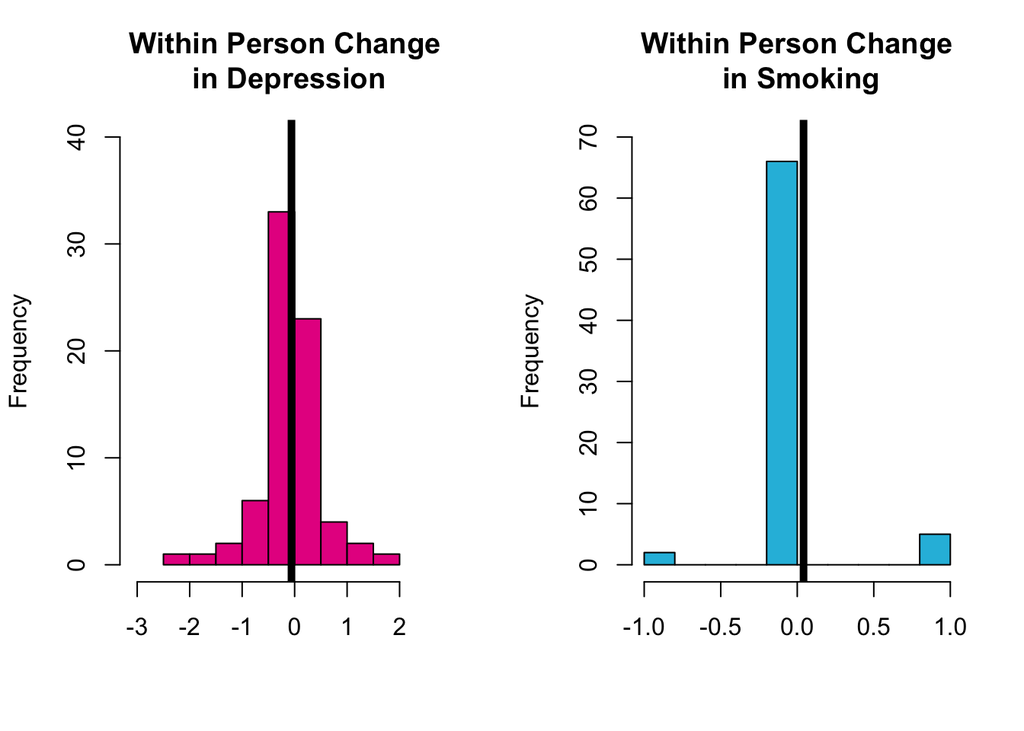

```r
# pull off the attributes for each wave
dep1 <- gaNetT1 %v% "depression.w1"
dep2 <- gaNetT2 %v% "depression.w2"
smk1 <- gaNetT1 %v% "smoker.w1"
smk2 <- gaNetT2 %v% "smoker.w2"


# create the deviations
depD <- dep2 - dep1
smkD <- smk2 - smk1


# set the partition
par( mfrow = c( 1, 2 ) )

# plot the within person deviations
hist( depD,
      col = "#e62090",
      main = "Within Person Change\n in Depression",
      ylim = c( 0, 40 ),
      xlim = c( min( depD )-1, max( depD )+1 ),
      xlab = ""
      )
abline( v = mean( depD ),
        lwd = 5,
        col = "black"
        )

# plot the within person deviations
hist( smkD,
      col = "#26bcde",
      main = "Within Person Change\n in Smoking",
      ylim = c( 0, 70 ),
      xlim = c( min( smkD ), max( smkD ) ),
      xlab = ""
      )
abline( v = mean( smkD ),
        lwd = 5,
        col = "black"
        )
```

*What do the plots tell us about changes to depression and smoking?*

## **Steps 1-5**

Ok, now that we have our attributes, let’s build our model:

```r
# build the dependent variables
depression <- sienaDependent( cbind( dep1, dep2 ), type = "behavior" )
smoking    <- sienaDependent( cbind( smk1, smk2 ), type = "behavior" )

# bind data together for Siena analysis
CoEvolutionData2 <- sienaDataCreate(
  getalong,          # our network
  depression,        # depression
  smoking            # smoking
  )

# create the effects object
CoEvolutionEffects2 <- getEffects( CoEvolutionData2 )

# create a model that has particulars about estimation, then we estimate the model
CoEvolutionModel2 <- sienaModelCreate( projname = "Get Along & Depression & Smoking", seed=605 )
```

```
## If you use this algorithm object, siena07 will create/use an output file Get Along & Depression & Smoking.txt .
```

```r
# estimate the model
CoEvolutionResults2 <- siena07(
  CoEvolutionModel2,
  data=CoEvolutionData2,
  effects=CoEvolutionEffects2
)

# look at the results
CoEvolutionResults2
```

```
## Estimates, standard errors and convergence t-ratios
##
##                                          Estimate   Standard   Convergence
##                                                       Error      t-ratio
## Network Dynamics
##   1. rate basic rate parameter getalong   6.4107  ( 0.5707   )    0.0752
##   2. eval outdegree (density)            -2.1242  ( 0.0842   )   -0.0483
##   3. eval reciprocity                     1.6857  ( 0.1879   )   -0.0748
##
## Behavior Dynamics
##   4. rate <1> rate depression period 1    1.2991  ( 0.3703   )    0.0028
##   5. eval <1> depression linear shape    -0.3841  ( 0.3048   )    0.0343
##   6. eval <1> depression quadratic shape -1.0757  ( 0.8004   )    0.0440
##   7. rate <2> rate smoking period 1       0.2047  ( 0.0918   )    0.0028
##   8. eval <2> smoking linear shape        0.2597  ( 0.7906   )   -0.0898
##
## Overall maximum convergence ratio:    0.1563
##
##
## Total of 2803 iteration steps.
```

*What are the interpretation of the rate and shape terms for depression and smoking?*

### **Adding Terms**

#### **Behavior Effects on the Network**

Now we want to include the effects of `depression` and `smoking` on tie behavior. We will use the same `egoX`, `altX`, and `sameX` or `simX` terms.

```r
CoEvolutionEffects2 <- includeEffects( CoEvolutionEffects2, egoX, altX, simX, interaction1 = "depression" )
```

```
##   effectName            include fix   test  initialValue parm
## 1 depression alter      TRUE    FALSE FALSE          0   0
## 2 depression ego        TRUE    FALSE FALSE          0   0
## 3 depression similarity TRUE    FALSE FALSE          0   0
```

```r
CoEvolutionEffects2 <- includeEffects( CoEvolutionEffects2, egoX, altX, sameX, interaction1 = "smoking" )
```

```
##   effectName    include fix   test  initialValue parm
## 1 smoking alter TRUE    FALSE FALSE          0   0
## 2 smoking ego   TRUE    FALSE FALSE          0   0
## 3 same smoking  TRUE    FALSE FALSE          0   0
```

*In the last line above, why did we use `sameX` and not `simX`?*

#### **Network Effects on Behavior**

Now we want to include the effects of the *get along with* network on the measures of *depression* and *smoking*. We will again use `outdeg`, `indeg`, and `avSim`.

```r
CoEvolutionEffects2 <- includeEffects( CoEvolutionEffects2, name = "depression", indeg, outdeg, avSim, interaction1="getalong" )
```

```
##   effectName                    include fix   test  initialValue parm
## 1 depression average similarity TRUE    FALSE FALSE          0   0
## 2 depression indegree           TRUE    FALSE FALSE          0   0
## 3 depression outdegree          TRUE    FALSE FALSE          0   0
```

```r
CoEvolutionEffects2 <- includeEffects( CoEvolutionEffects2, name = "smoking", indeg, outdeg, avSim, interaction1="getalong" )
```

```
##   effectName                 include fix   test  initialValue parm
## 1 smoking average similarity TRUE    FALSE FALSE          0   0
## 2 smoking indegree           TRUE    FALSE FALSE          0   0
## 3 smoking outdegree          TRUE    FALSE FALSE          0   0
```

Now we are ready to estimate the model (again)!

```r
CoEvolutionEffects2 <- siena07( CoEvolutionModel2, data = CoEvolutionData2, effects = CoEvolutionEffects2 )
CoEvolutionEffects2
```

```
## Estimates, standard errors and convergence t-ratios
##
##                                              Estimate   Standard      Convergence
##                                                           Error         t-ratio
## Network Dynamics
##    1. rate basic rate parameter getalong       5.9039 (      0.7052 )   -0.6571
##    2. eval outdegree (density)                -2.1238 (      0.3819 )   -0.2049
##    3. eval reciprocity                         1.7252 (      1.0327 )    0.0698
##    4. eval depression alter                   -0.2013 (      0.5205 )   -0.4096
##    5. eval depression ego                      0.0217 (      0.9264 )   -0.0124
##    6. eval depression similarity               1.2172 (      4.3319 )    0.3179
##    7. eval smoking alter                      -0.3665 (      0.6584 )    0.4133
##    8. eval smoking ego                        -0.5656 (      0.3618 )    0.3094
##    9. eval same smoking                       -0.1900 (      0.5350 )   -0.3831
##
## Behavior Dynamics
##   10. rate <1> rate depression period 1        1.5777 (      2.0742 )    0.3801
##   11. eval <1> depression linear shape         0.2478 (      2.9723 )    0.3566
##   12. eval <1> depression quadratic shape     -0.8268 (      4.5132 )    0.1996
##   13. eval <1> depression average similarity   1.8083 (     11.0245 )    0.7328
##   14. eval <1> depression indegree            -0.0373 (      0.9911 )    0.5794
##   15. eval <1> depression outdegree           -0.1123 (      0.6647 )    0.6793
##   16. rate <2> rate smoking period 1           0.1528 (      0.2235 )   -0.1967
##   17. eval <2> smoking linear shape           25.6622 (  21251.8960 )    0.0512
##   18. eval <2> smoking average similarity    123.7333 ( 102386.9365 )   -0.3415
##   19. eval <2> smoking indegree               55.0565 (  45360.6141 )   -0.0907
##   20. eval <2> smoking outdegree             -21.9846 (  18348.9309 )    0.2756
##
## Overall maximum convergence ratio:    1.9345
##
##
## Total of 3619 iteration steps.
```

*What are the interpretations of the coefficients?*

# **Wrapping up…**

In this lab we worked through examining the coevolution of networks and behavior with SABMs using the `RSiena` package. For WAY MORE details about `RSiena`, please review the [RSiena manual](http://www.stats.ox.ac.uk/~snijders/siena/RSiena_Manual.pdf).

### *Questions?*

##### *Please* report any needed corrections to the [Issues](https://github.com/jacobtnyoung/SAND/issues/new) page. Thanks!

[Back to SAND main page](https://jacobtnyoung.github.io/SAND/)